# Turning the wheels of time — A reproducibility case study

2017-03-07

# Installing R and RStudio

- You can get R from CRAN: https://cran.r-project.org/
- Then, install RStudio: https://www.rstudio.com/
- You can install packages easily from within RStudio via a call like this:

```r
install.packages("rmdformats")
```

- And then load them via a call like this:

```r
library("rmdformats")
```

# Our case study: Turning the wheels of time

Topolinski and Sparenberg (2012, press release in German [here](https://www.uni-wuerzburg.de/sonstiges/meldungen/single/artikel/wer-mit-de/)) report that clockwise movements induce psychological states of temporal progression and an orientation toward the future and novelty.

Among other experiments, they tested whether self–reported experiential openness is influenced by rotational movements.

The authors use the “Openness to Experience” subscale from the “Neuroticism – Extroversion – Openness” personality inventory ([NEO](https://en.wikipedia.org/wiki/Revised_NEO_Personality_Inventory#Personality_dimensions)) for their study.

They found that participants who turn kitchen rolls clockwise report more openness to new experiences (Experiment 2 in their paper), if one controls for mood and arousal.

In 2015 [Wagenmakers et. al.](http://dx.doi.org/10.3389/fpsyg.2015.00494) published a replications study that could not confirm these results.

The full data are available at https://osf.io/uszvx/, and as part of the JASP program with the name `Kitchen_Rolls.csv`.

# Importing the data

Here, we first load the R–package “[tidyverse](http://tidyverse.org/)”. It acts as a wrapper for a lot of very useful R packages. As the data comes in a csv format, we can use the function `read_csv` from the tidyverse to import it and display a preview.

Note that the function `read_csv` will print a message indicating the column specifications it has picked up.

The data can be conveniently viewed using `View()` in RStudio.

```r
library(tidyverse)
k_rolls <- read_csv("../data_and_papers_reproducibility/Kitchen_Rolls.csv")
k_rolls
```

```
# A tibble: 102 × 25
   ParticipantNumber Condition q1_check q2_check q1_NEO q2_NEO q3_NEO
               <int>     <int>    <int>    <int>  <int>  <int>  <int>
1                  1         1        2        6      4      2      1
2                  2         2        3        5      5      3      4
3                  3         3        7        3      4      2      4
4                  4         4        4        5      3      3      2
5                  5         1        3        3      1      1      1
6                  6         2        3        1      3      5      4
7                  7         3        4        7      5      4      2
8                  8         4        7        2      4      5      4
9                  9         1        5        3      5      4      4
 [ reached getOption("max.print") -- omitted 1 row ]
# ... with 92 more rows, and 18 more variables: q4_NEO <int>,
#   q5_NEO <int>, q6_NEO <int>, q7_NEO <int>, q8_NEO <int>, q9_NEO <int>,
#   q10_NEO <int>, q11_NEO <int>, q12_NEO <int>, mean_NEO <dbl>,
#   q3_check <int>, q4_check <int>, Include <lgl>, Rotation <chr>,
#   Age <int>, Sex <chr>, Student <chr>, Major.Occupation <chr>
```

# Produce a beeswarm plot of the data

We can check graphically, whether there is a relationship between turning and openness by looking at the **mean_Neo** variable. We use the package **ggplot2** for the plotting.

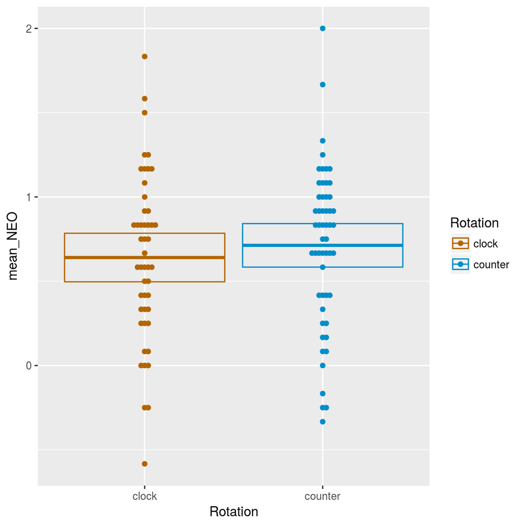

```r
d_for_ana <- select(k_rolls, ParticipantNumber, Rotation, mean_NEO)

library(ggbeeswarm)
library(Hmisc)


ggplot(d_for_ana, aes(x = Rotation, y = mean_NEO, color = Rotation)) + geom_beeswarm() +
    scale_color_hue(h.start = 30, l = 50) + stat_summary(fun.data = mean_cl_normal,
    geom = "crossbar")
```

# Perform a t-test to compare the two groups

We can now run a t-test to check whether our visual impression is correct, i.e. that there isn’t actually a difference between the two experimental groups.

```r
t.test(mean_NEO ~ Rotation, data = d_for_ana)
```

```
    Welch Two Sample t-test

data:  mean_NEO by Rotation
t = -0.75149, df = 97.315, p-value = 0.4542
alternative hypothesis: true difference in means is not equal to 0
95 percent confidence interval:
 -0.2633780  0.1187021
sample estimates:
  mean in group clock mean in group counter
             0.640625              0.712963
```